# Lab 3 Caloric Intake and Demographics

Week 5 R Fundamentals

Tony Lim

# 1. Overview

The goal of this analysis is to explore the relationship between total caloric intake, including beer consumption, and demographic factors. We will utilize some important R tools, including data importing, merging, summarizing by groups, and linear and log-linear regression.

# 2. Data Collection and Merging

We will use 2 datasets from the National Health and Nutrition Examination Survey (NHANES) for 2015-2016. Note, the dataset `TOTAL_CALORIES` was previously created using the NHANES datasets `DR1IFF_I.XPT` (on daily food consumption) and `DRXFCD_I.XPT` (on food codes) available at https://wwwn.cdc.gov/nchs/nhanes/Default.aspx.

**DEMO**

- **SEQN:** Survey respondant’s sequence number
- **AGE:** Age of respondant (years)
- **GENDER:** Biological sex of respondant
- **EDUCATION:** Education level of respondant (“Less than High School”, “High School”, “Some College”, “College Grad”)

**TOTAL_CALORIES**

- **SEQN:** Survey respondant’s sequence number
- **ALL_CALORIES:** Total calories consumed (food + drinks) by respondant in past 24 hours
- **BEER_CALORIES:** Calories consumed from beer in past 24 hours

Use `read_csv()` to load each dataset for analysis.

```r
library(dplyr)
library(ggplot2)
library(jtools)
library(readr)
```

```r
DEMO <- read_csv("DEMO.csv") %>%
  print(width = Inf)
```

```
## # A tibble: 5,719 x 4
##     SEQN GENDER   AGE EDUCATION
##    <dbl> <chr>  <dbl> <chr>
##  1 83732 Male      62 College Grad
##  2 83733 Male      53 High School
##  3 83734 Male      78 High School
##  4 83735 Female    56 College Grad
##  5 83736 Female    42 Some College
##  6 83737 Female    72 Less than High School
##  7 83741 Male      22 Some College
##  8 83742 Female    32 Some College
##  9 83744 Male      56 High School
## 10 83747 Male      46 College Grad
## # ... with 5,709 more rows
```

```r
TOTAL_CALORIES <- read_csv("TOTAL_CALORIES.csv") %>%
  print(width = Inf)
```

```
## # A tibble: 8,505 x 3
##     SEQN ALL_CALORIES BEER_CALORIES
##    <dbl>        <dbl>         <dbl>
##  1 83732         1781             0
##  2 83733         2964           835
##  3 83734         2482             0
##  4 83735         1340             0
##  5 83736          604             0
##  6 83737         1304             0
##  7 83738         1239             0
##  8 83739         1242             0
##  9 83740         1151             0
## 10 83741         2338             0
## # ... with 8,495 more rows
```

## Question 1

After loading the dplyr library, use `full_join()` to merge the datasets using `SEQN` as the common link. Name this new dataset FULL. How many observations are in FULL?

```r
FULL  <- full_join(DEMO, TOTAL_CALORIES, by = "SEQN") %>%
  print(width = Inf)
```

```
## # A tibble: 9,207 x 6
##     SEQN GENDER   AGE EDUCATION             ALL_CALORIES BEER_CALORIES
##    <dbl> <chr>  <dbl> <chr>                        <dbl>         <dbl>
##  1 83732 Male      62 College Grad                  1781             0
##  2 83733 Male      53 High School                   2964           835
##  3 83734 Male      78 High School                   2482             0
##  4 83735 Female    56 College Grad                  1340             0
##  5 83736 Female    42 Some College                   604             0
##  6 83737 Female    72 Less than High School         1304             0
##  7 83741 Male      22 Some College                  2338             0
##  8 83742 Female    32 Some College                  2387             0
##  9 83744 Male      56 High School                   1077             0
## 10 83747 Male      46 College Grad                  1528             0
## # ... with 9,197 more rows
```

With `full_join()`, we have 9,207 observations.

## Question 2

Use `inner_join()` to merge the datasets using `SEQN` as the common link. Name this new dataset `INNER`. How many observations are in INNER?

```r
INNER <- inner_join(DEMO, TOTAL_CALORIES, by = "SEQN") %>%
  print(width = Inf)
```

```
## # A tibble: 5,017 x 6
##     SEQN GENDER   AGE EDUCATION             ALL_CALORIES BEER_CALORIES
##    <dbl> <chr>  <dbl> <chr>                        <dbl>         <dbl>
##  1 83732 Male      62 College Grad                  1781             0
##  2 83733 Male      53 High School                   2964           835
##  3 83734 Male      78 High School                   2482             0
##  4 83735 Female    56 College Grad                  1340             0
##  5 83736 Female    42 Some College                   604             0
##  6 83737 Female    72 Less than High School         1304             0
##  7 83741 Male      22 Some College                  2338             0
##  8 83742 Female    32 Some College                  2387             0
##  9 83744 Male      56 High School                   1077             0
## 10 83747 Male      46 College Grad                  1528             0
## # ... with 5,007 more rows
```

With `inner_join()`, we have 5,017 observations.

We will use `INNER` in the remainder of the lab, as we want only to include only those individuals with both demographic information and calorie consumption data.

# 3. Data Exploration

Let’s calculate the mean and standard deviation of `TOTAL` calories by gender using the following code:

```r
tapply(INNER$ALL_CALORIES, INNER$GENDER, mean)
```

```
##   Female     Male
## 1799.294 2373.886
```

```r
tapply(INNER$ALL_CALORIES, INNER$GENDER, sd)
```

```
##    Female      Male
##  761.1476 1039.2565
```

Women have an average total caloric consumption of 1799.3 with a standard deviation of 761.1. Men have an average total caloric consumption of 2373.9 with a standard deviation of 1039.3.

## Question 3

What are the mean `BEER` calories consumed by men and women?

```r
tapply(INNER$BEER_CALORIES, INNER$GENDER, mean)
```

```
##   Female     Male
## 16.64873 92.40248
```

On average, men consume 92.4 beer calories while women consume 16.6 beer calories.

## Question 4

Consumers with which education level consume the most `TOTAL` calories? And the most `BEER` calories?

```r
tapply(INNER$ALL_CALORIES, INNER$EDUCATION, mean)
```

```
##          College Grad           High School Less than High School
##              2119.723              2099.590              1976.451
##          Some College
##              2097.877
```

```r
tapply(INNER$BEER_CALORIES, INNER$EDUCATION, mean)
```

```
##          College Grad           High School Less than High School
##              32.00870              77.67329              59.13715
##          Some College
##              48.11863
```

On average, college graduates consume the most total calories (2119.7), but individuals with a high school degree consume the most beer calories (77.7).

# 4. Data Visualization

## Question 5

Create a histogram of total caloric consumption by gender, using `ggplot()` and `facet_wrap()` with different colors.

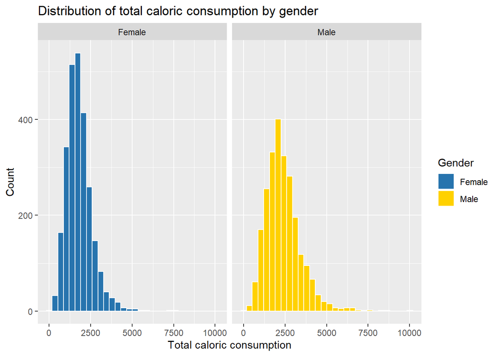

```r
INNER %>%
  ggplot() +
  geom_histogram(mapping = aes(x = ALL_CALORIES, fill = GENDER),
                 color = "white",
                 bins = 30) +
  labs(title = "Distribution of total caloric consumption by gender",
       x = "Total caloric consumption",
       y = "Count") +
  scale_fill_manual(name = "Gender", values = c("#2774AE", "#FFD100")) +
  facet_wrap(~ GENDER)
```

# 5. Linear Regression Analysis

## Question 6

Regress `TOTAL` calories on age, gender, and education using the `INNER` data.

```r
reg1 <- lm(ALL_CALORIES ~ AGE + GENDER+ EDUCATION, data = INNER)

summ(reg1)
```

```
## MODEL INFO:
## Observations: 5017
## Dependent Variable: ALL_CALORIES
## Type: OLS linear regression
##
## MODEL FIT:
## F(5,5011) = 147.20, p = 0.00
## R² = 0.13
## Adj. R² = 0.13
##
## Standard errors: OLS
## -------------------------------------------------------------
##                                  Est.    S.E.   t val.      p
## --------------------------- --------- ------- -------- ------
## (Intercept)                   2306.24   43.82    52.64   0.00
## AGE                             -9.72    0.72   -13.58   0.00
## GENDERMale                     584.32   25.12    23.26   0.00
## EDUCATIONHigh School           -20.64   36.57    -0.56   0.57
## EDUCATIONLess than High       -105.78   36.40    -2.91   0.00
## School
## EDUCATIONSome College           -1.09   33.93    -0.03   0.97
## -------------------------------------------------------------
```

## Question 7

Regress `BEER` calories on age, gender, and education using the `INNER` data.

```r
reg2 <- lm(BEER_CALORIES ~ AGE + GENDER + EDUCATION, data = INNER)

summ(reg2)
```

```
## MODEL INFO:
## Observations: 5017
## Dependent Variable: BEER_CALORIES
## Type: OLS linear regression
##
## MODEL FIT:
## F(5,5011) = 45.99, p = 0.00
## R² = 0.04
## Adj. R² = 0.04
##
## Standard errors: OLS
## -----------------------------------------------------------
##                                Est.    S.E.   t val.      p
## --------------------------- ------- ------- -------- ------
## (Intercept)                   46.36   10.29     4.50   0.00
## AGE                           -1.05    0.17    -6.24   0.00
## GENDERMale                    75.32    5.90    12.77   0.00
## EDUCATIONHigh School          45.15    8.59     5.26   0.00
## EDUCATIONLess than High       30.76    8.55     3.60   0.00
## School
## EDUCATIONSome College         18.73    7.97     2.35   0.02
## -----------------------------------------------------------
```

Finally, let’s use our regressions to make a prediction for a friend. We make a small dataframe called `FRIEND` and enter some input values for the regression.

```r
FRIEND <- data.frame(
  AGE = 25,
  GENDER = "Male",
  EDUCATION = "College Grad"
  )
```

Then we enter this information into the `predict()` command. We can also obtain a 95% prediction interval.

```r
predict(reg1, newdata = FRIEND, interval = "prediction")
```

```
##        fit      lwr      upr
## 1 2647.653 906.3977 4388.909
```

## Question 8

Your neighbor is an Instagram influencer who is 32, attended some college, and is female. What is her predicted calorie consumption?

```r
NEIGHBOR <- data.frame(
  AGE = 32,
  GENDER = "Female",
  EDUCATION = "Some College"
  )

predict(reg1, newdata = NEIGHBOR, interval = "prediction")
```

```
##        fit      lwr      upr
## 1 1994.228 253.2895 3735.166
```